# Workflow 6- CNN Building Image Classification

## Aim

1. Tensorflow Classification Script
2. Running Tensorflow CNN Classification Workflow on the Master Data Set
3. Compare Ground Truth with CNN Predictions
4. Create Confusion Tables for Classification Results

## Method

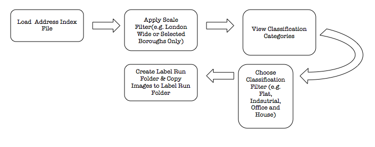

## Set Up

```python
## Load Librarys and Jupyter User Settings
from IPython.core.display import display, HTML
display(HTML("<style>.container { width:760 !important; }</style>"))
#Run Multiple Commands in One Cell
from IPython.core.interactiveshell import InteractiveShell
InteractiveShell.ast_node_interactivity = "all"
#Get All DataFrame Columns
import pandas as pd
pd.set_option('display.max_colwidth', -1)
import numpy as np
pd.set_option('display.max_columns', None)
import os
import matplotlib.pyplot as plt
import matplotlib.image as mpimg
from IPython.core.display import display, HTML, Markdown
#display(HTML("<style>.container { width:100% !important; }</style>"))
```

```python
def plotdat(data,cat):
    l=data.groupby(cat).size()
    l.sort_values()
    #fig=plt.figure(figsize=(10,5))
    fig=plt.figure(figsize=(25,5))
    plt.yticks(fontsize=8)
    l.plot(kind='bar',fontsize=14,color='k')
    plt.xlabel('')
    plt.ylabel('Number of ...',fontsize=10)
```

```python
## Thumb Gallery Helper
def css_styling():
    styles = open('custom_thumbs.css', 'r').read()
    return HTML(styles)
css_styling()

## Table Label Helper
def printmd(string):
    display(Markdown(string))
```

## 1 - Tensorflow Image Classification Script

```python
#
# Copyright 2017 The TensorFlow Authors. All Rights Reserved.
#
# Licensed under the Apache License, Version 2.0 (the "License");
# you may not use this file except in compliance with the License.
# You may obtain a copy of the License at
#
#     http://www.apache.org/licenses/LICENSE-2.0
#
# Unless required by applicable law or agreed to in writing, software
# distributed under the License is distributed on an "AS IS" BASIS,
# WITHOUT WARRANTIES OR CONDITIONS OF ANY KIND, either express or implied.
# See the License for the specific language governing permissions and
# limitations under the License.
# ==============================================================================

from __future__ import absolute_import
from __future__ import division
from __future__ import print_function

import argparse

import numpy as np
import tensorflow as tf


def load_graph(model_file):
    graph = tf.Graph()
    graph_def = tf.GraphDef()

    with open(model_file, "rb") as f:
        graph_def.ParseFromString(f.read())
    with graph.as_default():
        tf.import_graph_def(graph_def)

    return graph


def read_tensor_from_image_file(file_name,
                                input_height=299,
                                input_width=299,
                                input_mean=0,
                                input_std=255):
    input_name = "file_reader"
    output_name = "normalized"
    file_reader = tf.read_file(file_name, input_name)
    if file_name.endswith(".png"):
        image_reader = tf.image.decode_png(
            file_reader, channels=3, name="png_reader")
    elif file_name.endswith(".gif"):
        image_reader = tf.squeeze(
            tf.image.decode_gif(file_reader, name="gif_reader"))
    elif file_name.endswith(".bmp"):
        image_reader = tf.image.decode_bmp(file_reader, name="bmp_reader")
    else:
        image_reader = tf.image.decode_jpeg(
            file_reader, channels=3, name="jpeg_reader")
    float_caster = tf.cast(image_reader, tf.float32)
    dims_expander = tf.expand_dims(float_caster, 0)
    resized = tf.image.resize_bilinear(dims_expander, [input_height, input_width])
    normalized = tf.divide(tf.subtract(resized, [input_mean]), [input_std])
    sess = tf.Session()
    result = sess.run(normalized)

    return result


def load_labels(label_file):
    label = []
    proto_as_ascii_lines = tf.gfile.GFile(label_file).readlines()
    for l in proto_as_ascii_lines:
        label.append(l.rstrip())
    return label


def main(image, model, label):

    input_mean = 0
    input_std = 255
    file_name = image
    model_file = model
    label_file = label
    input_height = 224
    input_width = 224
    input_mean = 128
    input_std = 128

    input_layer="Placeholder"
    output_layer="final_result"

    graph = load_graph(model_file)
    t = read_tensor_from_image_file(
      file_name,
      input_height=input_height,
      input_width=input_width,
      input_mean=input_mean,
      input_std=input_std)

    input_name = "import/" + input_layer
    output_name = "import/" + output_layer
    input_operation = graph.get_operation_by_name(input_name)
    output_operation = graph.get_operation_by_name(output_name)

    with tf.Session(graph=graph) as sess:
        results = sess.run(output_operation.outputs[0], {
            input_operation.outputs[0]: t
        })
    results = np.squeeze(results)

    top_k = results.argsort()[-5:][::-1]
    labels = load_labels(label_file)

    template = "{} (score={:0.5f})"
    template2 = "{:0.5f}"

    for i in top_k:
        #print(top_k[0])
        #print(i)
        print(template.format(labels[i], results[i]))

    #print(labels[1])
    #print(results[1])

    #top_k tweak added by Anthony Sutton
    winner = top_k[0]
    return labels[winner], template2.format(results[winner])
```

## Model Selection

```python
#/Users/anthonysutton/ml2/tensorflow-for-poets-2/tf_files/train_runs/run_63
#/Users/anthonysutton/ml2/tensorflow-for-poets-2/tf_files/train_runs/run_71
#/Users/anthonysutton/ml2/tensorflow-for-poets-2/tf_files/train_runs/run_81
#/Users/anthonysutton/ml2/tensorflow-for-poets-2/tf_files/train_runs/run_46

# Get the Trained model layer to run on our data:
TensorBoardSummaryFolder = input("Please enter location of Weights File:")
```

```
Please enter location of Weights File:/Users/anthonysutton/ml2/tensorflow-for-poets-2/tf_files/train_runs/run_227
```

### Quick Test

```python
#/Users/anthonysutton/ml2/_FINAL_SCRIPT_LIBRARY/LABELS/TEST_SET/Test_Data_3/LDD_Test_Set_Complete/SV_RUN1/col_id_10040.jpg
ChosenImageFile = "/Users/anthonysutton/ml2/_DATA_LABELS/BUILD_INST/ARCHIVE/garage/garage_0010.jpg"
```

```
Current size: [12.0, 9.0]
```

```
flat (score=0.49200)
office (score=0.35232)
house (score=0.13462)
industrial (score=0.02106)
flat 0.49200
```

[figure not shown]

```python
#Quick Test of Script and libraries
img=mpimg.imread(ChosenImageFile)

# Get current size
fig_size = plt.rcParams["figure.figsize"]

# Prints: [8.0, 6.0]
print ("Current size:", fig_size)

# Set figure width to 12 and height to 9
fig_size[0] = 12
fig_size[1] = 9
plt.rcParams["figure.figsize"] = fig_size

plt.imshow(img)

# Quick check of Parameters:
image = ChosenImageFile
model = TensorBoardSummaryFolder + '/retrained_graph.pb'
label_index = TensorBoardSummaryFolder + '/retrained_labels.txt'
#test, test2, category = main(image)
#category
#main(image)
test, test2 = main(image, model, label_index )
print(test, test2)
```

```python
image = ChosenImageFile
model = TensorBoardSummaryFolder + '/retrained_graph.pb'
label_index = TensorBoardSummaryFolder + '/retrained_labels.txt'
label_name, score = main(image, model, label_index)
print(label_name, score)
```

[output not shown]

# 2 - Running Tensorflow CNN Classification Workflow on the Master Test Data Set

### Select Model

```python
#/Users/anthonysutton/ml2/tensorflow-for-poets-2/tf_files/train_runs/run_63
TensorBoardSummaryFolder = input()
```

```
/Users/anthonysutton/ml2/tensorflow-for-poets-2/tf_files/train_runs/run_227
```

```python
#select saved transfer layer and labels synset
model = TensorBoardSummaryFolder + '/retrained_graph.pb'
label_index = TensorBoardSummaryFolder + '/retrained_labels.txt'
```

### Enter Folder Location of Images to be labelled

```python
# Not Needed for London Wide Test and Train Set Runs
#/Users/anthonysutton/ml2/_FINAL_SCRIPT_LIBRARY/LABELS/TEST_SET/Test_Data_3/LDD_Test_Set_Complete
#/Users/anthonysutton/ml2/_FINAL_SCRIPT_LIBRARY/LABELS/LABEL_RUN_50/df_cat_indust_test/SV_RUN1
#/Users/anthonysutton/ml2/_FINAL_SCRIPT_LIBRARY/LABELS/LABEL_RUN_50/df_cat_flats_no_conv_test/SV_RUN1
#/Users/anthonysutton/ml2/_FINAL_SCRIPT_LIBRARY/LABELS/LABEL_RUN_2_2_SAFE
#/Users/anthonysutton/ml2/_FINAL_SCRIPT_LIBRARY/LABELS/LABEL_RUN_63/TEST
#/Users/anthonysutton/ml2/image_similar/casa_images/10.jpg
#/Users/anthonysutton/ml2/_FINAL_SCRIPT_LIBRARY/LABELS/LABEL_RUN_68/TEST/_FLAT_HOUSE_INDUSTRIAL_RETAIL_OFFICE
FolderRunName = input()
```

```
/Users/anthonysutton/ml2/_FINAL_SCRIPT_LIBRARY/LABELS/LABEL_RUN_74/TEST
```

### Run CNN Image Classifier

```python
### Save Classification to Predicted Class column
#import os


rootdir = FolderRunName
labels = []
count = 1
for subdir, dirs, files in os.walk(rootdir):
    for file in files:
        #need to skip mac osx config file
        if file != '.DS_Store' :
                count = count + 1
                print(count)
                print(subdir + '/' + file)
                #out_file = dirs
                image = subdir + '/' + file
                label_name, score = main(image, model, label_index)
                #labelled = (1, 2, 3)
                # Remove suffix
                file_name = file[:-4]
                # Keep TempID
                #Check FileName format if needed:
                file_name = file_name[7:]

                #print('ln->' + label_name, score)
                labelled = (file_name, label_name, score)
                #Get Labels for non LDD Labels
                true_label = os.path.basename(os.path.dirname(image))
                labelled = (file_name, label_name, score, true_label)
                print(labelled)
                labels.append(labelled)

print("Done")
```

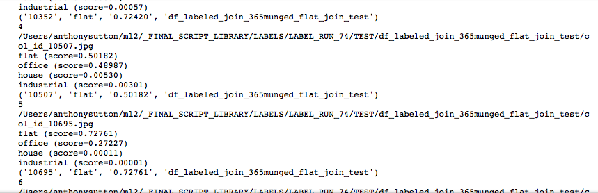

```python
### Save Classification to Predicted Class column
#import os


rootdir = FolderRunName
labels = []
count = 1
for subdir, dirs, files in os.walk(rootdir):
    for file in files:
        #need to skip mac osx config file
        if file != '.DS_Store' :
                count = count + 1
                print(count)
                print(subdir + '/' + file)
                #out_file = dirs
                image = subdir + '/' + file
                label_name, score = main(image, model, label_index)
                #labelled = (1, 2, 3)
                # Remove suffix
                file_name = file[:-4]
                # Keep TempID
                #Check FileName format if needed:
                file_name = file_name[7:]

                #print('ln->' + label_name, score)
                labelled = (file_name, label_name, score)
                #Get Labels for non LDD Labels
                true_label = os.path.basename(os.path.dirname(image))
                labelled = (file_name, label_name, score, true_label)
                print(labelled)
                labels.append(labelled)

print("Done")
```

[figure not shown]

a = np.asarray(labels) np.savetxt("london_all_labelled_test_14.csv", a, fmt='%5s',delimiter=",", header="TempID,Predicted_Label,Label_Score", comments="") # Save Colum Names

```python
#non ldd labels
a = np.asarray(labels)
np.savetxt("london_all_labelled_test_29.csv", a, fmt='%5s',delimiter=",", header="TempID,Predicted_Label,Label_Score,C_Truth", comments="")
# Save Colum Names
```

```python
model
```

```
'/Users/anthonysutton/ml2/tensorflow-for-poets-2/tf_files/train_runs/run_227/retrained_graph.pb'
```

# 3 - Compare Ground Truth with CNN Predictions

## Join Labelled Data to Master Data Model

```python
#kang only version
df_labels = pd.read_csv('london_all_labelled_test_29.csv',  sep=',',
                           error_bad_lines=False, index_col=False,  na_values=['.'], encoding="ISO-8859-1")

df_ldd_label_join = df_labels
```

```python
#kang only version
df_ldd = pd.read_csv('/Users/anthonysutton/ml2/_DATA_LABELS/LDD_STORE/LDD_MODEL/AB_LDD.csv',  sep=',',
                           error_bad_lines=False, index_col=False,  na_values=['.'], encoding="ISO-8859-1")


#AddBase Schema
#Load CSV
#Includes stripping for NULLs
df_ab_schema = pd.read_csv('LookUps/AB_Schema.csv',  sep=',',
                           error_bad_lines=False, index_col=False,  na_values=['.'], encoding="ISO-8859-1")

#Join Schema to Master Data
df_ldd_ab_sch_join = pd.merge(df_ldd, df_ab_schema, on='ClassificationCode' , how='left')

#ACORN - Only Load When creating Auxilary Label Sets
#Load CSV
#Includes stripping for NULLs
df_labels = pd.read_csv('london_all_labelled_test_29.csv',  sep=',',
                           error_bad_lines=False, index_col=False,  na_values=['.'], encoding="ISO-8859-1")

#Join the 2 x tables
df_ldd_label_join = pd.merge(df_ldd_ab_sch_join, df_labels, on='TempID' , how='inner')
#df_ldd_acorn_join = pd.merge(df_ldd, df_acorn, on='Postcode_Join' , how='left')

df_ldd_label_join

#df_ldd_Filter1.head(1)
#df_ldd_Filter1 = []


#Save to CSV
```

```python
df_ldd_label_join.shape
```

[output not shown]

```python
df_ldd_label_join.head(10)
```

### Create Ground Truth Feature

```python
df_ldd_label_join['C_Truth'] = df_ldd_label_join['Concatenated']
```

```python
# Original Version
df_ldd_label_join.C_Truth = df_ldd_label_join.C_Truth.replace({"RD06": "flats",
                                                   "RD02": "house", "RD03": "house", "RD04": "house"
                                                              }
                                                             )
df_ldd_label_join.loc[df_ldd_label_join['C_Truth'].str.startswith('CO'), 'C_Truth'] = 'office'
df_ldd_label_join.loc[df_ldd_label_join['C_Truth'].str.startswith('CR'), 'C_Truth'] = 'retail'
df_ldd_label_join.loc[df_ldd_label_join['C_Truth'].str.startswith('CI'), 'C_Truth'] = 'industrial'
```

```python
df_ldd_label_join.shape
#df_ldd_label_join.head(10)
```

[output not shown]

```python
#Revisit 2
df_ldd_label_join.C_Truth = df_ldd_label_join.C_Truth.replace({"RD06": "FLATS",
                                                   "RD02": "HOUSE", "RD03": "HOUSE", "RD04": "HOUSE"
                                                              }
                                                             )
df_ldd_label_join.loc[df_ldd_label_join['C_Truth'].str.startswith('CO'), 'C_Truth'] = 'office'
df_ldd_label_join.loc[df_ldd_label_join['C_Truth'].str.startswith('CR'), 'C_Truth'] = 'retail'
df_ldd_label_join.loc[df_ldd_label_join['C_Truth'].str.startswith('CI'), 'C_Truth'] = 'industrial'
```

## Save to CSV

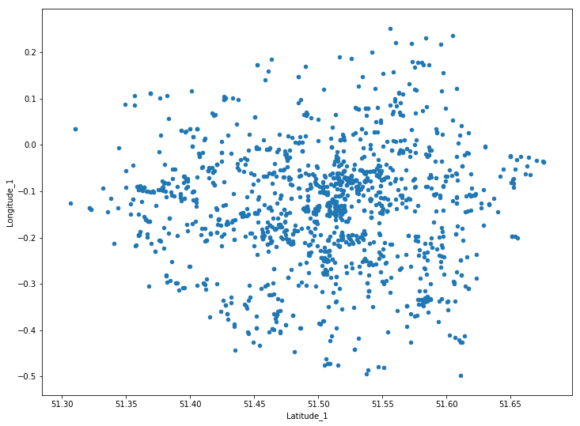

```python
header = ["TempID", "Latitude", "Longitude", "Dest Number", "Concatenated", "ClassificationCode", "Class_Desc", "Predicted_Label", "Label_Score", "C_Truth" ]
#df_ldd_label_join.to_csv('CASA_Log_Truth_Prediction_Labels_3.csv', columns = header, index=False)
df_ldd_label_join.to_csv('london_all_labelled_test_29.csv', columns = header, index=False)
df_ldd_label_join.plot(kind='scatter',x='Latitude_1',y='Longitude_1') # scatter plot
```

# Quick Inspection of Results

### Ground Truth - Property Type Distribution

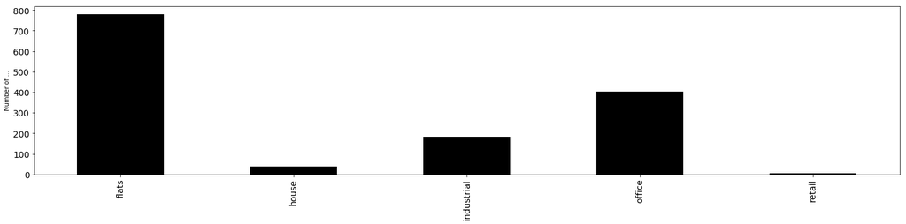

```python
#Check Distribution of Property Types FOR GROUND TRUTH
plotdat(df_ldd_label_join,'C_Truth')
```

### CNN Prediction - Property Type Distribution

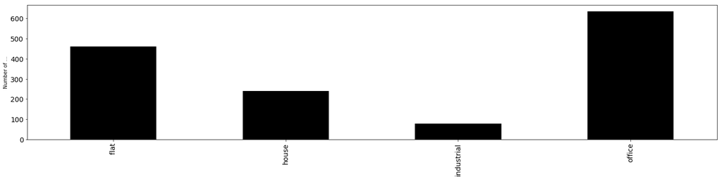

```python
#Check Distribution of Property Types FOR CLASSFIER
plotdat(df_ldd_label_join,'Predicted_Label')
```

```python
#df_label_join_import.loc[:,'C_Truth'] = df_ldd_label_join['Tertiary_Desc'].astype(str).str[0]
```

### Misclassified Images Thumb Gallery

```python
#df_ldd_label_join[['Predicted_Label', 'C_Truth']].assign(NE=df_ldd_label_join.Predicted_Label.astype(str) \
#                                                         != df_ldd_label_join.C_Truth.astype(str))



df_ldd_label_join_misclass = df_ldd_label_join.loc[~(df_ldd_label_join['Predicted_Label'] == df_ldd_label_join['C_Truth'])]
```

```python
df_ldd_label_join_misclass.shape
```

```
(1120, 106)
```

df_ldd_label_join.loc[~(df_ldd_label_join['Predicted_Label'] == df_ldd_label_join['C_Truth'])]

```python
df_ldd_label_join_misclass.head(10)
```

```python
df_ldd_label_join_goclass = df_ldd_label_join.loc[(df_ldd_label_join['Predicted_Label'] == df_ldd_label_join['C_Truth'])]
```

```python
## Load Librarys and Jupyter User Settings
from IPython.core.display import display, HTML
display(HTML("<style>.container { width:760 !important; }</style>"))
from IPython.display import Markdown, display, HTML
from IPython.display import Image as Img

def css_styling():
    styles = open('custom_thumbs.css', 'r').read()
    return HTML(styles)

css_styling()
```

```python
#printmd('<br><br><b>`' + title +'`</b> &#9663;<br><br>')
#the_frame = eval(d_frame)
#print(the_frame.shape)
#imagey = df_ldd_Filter1['TempID'].sample(n=1)
size = 2        # sample size
size = 2
replace = True  # with replacement
# Ensure we have n>100 Labels
thumbsdf = df_ldd_label_join_misclass.groupby('ClassificationCode').filter(lambda x : len(x)>size)
fn = lambda obj: obj.loc[np.random.choice(obj.index, size, replace),:]
thumb_gally = thumbsdf.groupby('ClassificationCode', as_index=False).apply(fn)
thumb_gally2 = thumb_gally[['TempID', 'ClassificationCode', 'C_Truth', 'Predicted_Label', 'Class_Desc']].values
gallery = ""

for count, element in enumerate(thumb_gally2, 1):
    if thumb_gally2[count-1,0] <= 29192:
        inp2 = '../../_STREETVIEW_EXPLORER/LDD_Complete/col_id_' + str(thumb_gally2[count-1,0]) +'.jpg'
    else:
        inp2 = '../../_STREETVIEW_EXPLORER/LDD_Complete/batch2/col_id_' + str(thumb_gally2[count-1,0]) +'.jpg'
    inp3 = "<div class='gallery'><div class='zoom'><img src='" +  inp2 + "' width='' height=''></div><div class='desc'>" + str(thumb_gally2[count-1,0]) + \
             ". Pred= _" + str(thumb_gally2[count-1,3]) + "_ Truth= _" + str(thumb_gally2[count-1,2]) +  "_</div></div>"
    gallery = gallery + inp3

display(HTML(gallery))
```

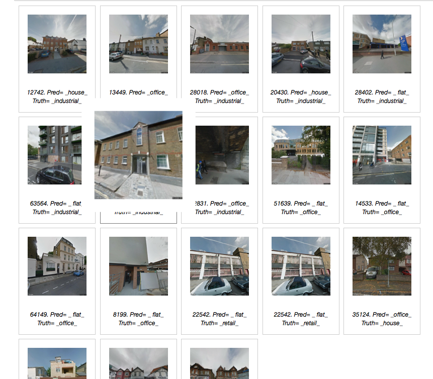

# 4 - Create Confusion Tables for Classification Results

```python
df_label_join_import = df_ldd_label_join
```

```python
from sklearn.metrics import confusion_matrix
from sklearn import preprocessing
import matplotlib.pyplot as plt
```

```python
#Import Predicted Results from earlier run
y_true = df_label_join_import['C_Truth'].values.astype(str)
x_pred = df_label_join_import['Predicted_Label'].values.astype(str)

#Live Run
#y_true = df_label_join['C_Truth'].values
#x_pred = df_label_join['Predicted_Label'].values
#x_pred = df_label_join['Predicted_Label'].values


leY = preprocessing.LabelEncoder()
leY.fit(y_true)
#list(leY.classes_)
Ynp = leY.transform(y_true)
leX = preprocessing.LabelEncoder()
leX.fit(x_pred)
list(leX.classes_)
Xnp = leX.transform(x_pred)
np.set_printoptions(threshold=np.nan)
#Ynp
```

```
LabelEncoder()
```

```
LabelEncoder()
```

```
[' flat', 'house', 'industrial', 'office']
```

```python
list(leX.classes_)
```

```
[' flat', 'house', 'industrial', 'office']
```

```python
#Quick Check of Results
df_label_join_import['C_Truth'].value_counts()
df_label_join_import['Predicted_Label'].value_counts()
df_label_join_import.shape
df_label_join_import.loc[df_label_join_import['C_Truth'] == df_label_join_import['Predicted_Label']].shape
```

```
flats         780
office        403
industrial    183
house         40
retail        5
Name: C_Truth, dtype: int64
```

```
office        635
 flat         460
house         239
industrial    77
Name: Predicted_Label, dtype: int64
```

```
(1411, 106)
```

```
(291, 106)
```

```python
#Baby Confusion Matrix
from sklearn.metrics import confusion_matrix
import matplotlib.pyplot as plt

#confusion_matrix = confusion_matrix(Ynp, Xnp)
#plt.matshow(confusion_matrix)
#plt.title('Confusion matrix')
#plt.colorbar()
#plt.ylabel('True label')
#plt.xlabel('Predicted label')
#plt.show()

conf_mat = confusion_matrix(Ynp, Xnp)
acc = np.sum(conf_mat.diagonal()) / np.sum(conf_mat)
print('Overall accuracy: {} %'.format(acc*100))
```

```
Overall accuracy: 40.11339475549256 %
```

```
Confusion matrix, without normalization
[[275 158  24 323   0]
 [ 10  23   2   5   0]
 [ 52  28  33  70   0]
 [120  30  18 235   0]
 [  3   0   0   2   0]]
```

```
Normalized confusion matrix
[[0.35 0.2  0.03 0.41 0.  ]
 [0.25 0.57 0.05 0.12 0.  ]
 [0.28 0.15 0.18 0.38 0.  ]
 [0.3  0.07 0.04 0.58 0.  ]
 [0.6  0.   0.   0.4  0.  ]]
```

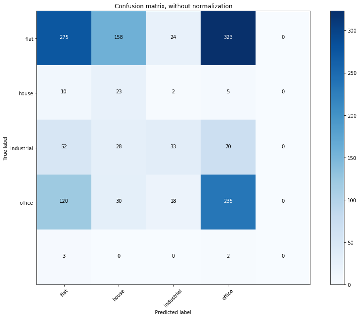

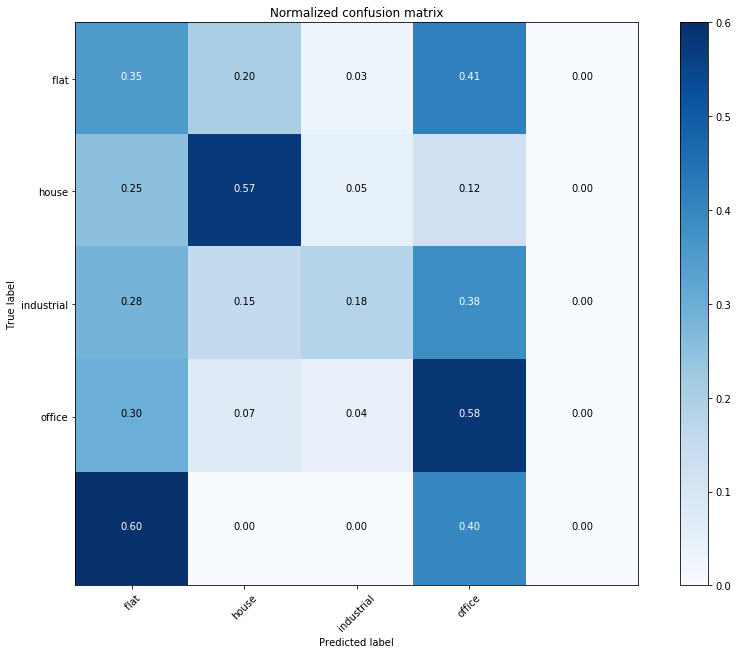

```python
#Final Version Confusion Matrix
import itertools
import numpy as np
import matplotlib.pyplot as plt

from sklearn import svm, datasets
from sklearn.model_selection import train_test_split
from sklearn.metrics import confusion_matrix

# import some data to play with
#iris = datasets.load_iris()
#X = iris.data
#y = iris.target
#class_names = iris.target_names
class_names = [' flat', 'house', 'industrial', 'office', 'retail']

class_names = list(leX.classes_)
# Split the data into a training set and a test set
#X_train, X_test, y_train, y_test = train_test_split(X, y, random_state=0)

# Run classifier, using a model that is too regularized (C too low) to see
# the impact on the results
#classifier = svm.SVC(kernel='linear', C=0.01)
#y_pred = classifier.fit(X_train, y_train).predict(X_test)


def plot_confusion_matrix(cm, classes,
                          normalize=False,
                          title='Confusion matrix',
                          cmap=plt.cm.Blues):
    """
    This function prints and plots the confusion matrix.
    Normalization can be applied by setting `normalize=True`.
    """
    if normalize:
        cm = cm.astype('float') / cm.sum(axis=1)[:, np.newaxis]
        print("Normalized confusion matrix")
    else:
        print('Confusion matrix, without normalization')

    print(cm)

    plt.imshow(cm, interpolation='nearest', cmap=cmap)
    plt.title(title)
    plt.colorbar()
    tick_marks = np.arange(len(classes))
    plt.xticks(tick_marks, classes, rotation=45)
    plt.yticks(tick_marks, classes)

    fmt = '.2f' if normalize else 'd'
    thresh = cm.max() / 2.
    for i, j in itertools.product(range(cm.shape[0]), range(cm.shape[1])):
        plt.text(j, i, format(cm[i, j], fmt),
                 horizontalalignment="center",
                 color="white" if cm[i, j] > thresh else "black")

    plt.tight_layout()
    plt.ylabel('True label')
    plt.xlabel('Predicted label')

# Compute confusion matrix
cnf_matrix = confusion_matrix(Ynp, Xnp)
np.set_printoptions(precision=2)

# Plot non-normalized confusion matrix
plt.figure()
plot_confusion_matrix(cnf_matrix, classes=class_names,
                      title='Confusion matrix, without normalization')
plt.savefig('confusion3a.png')

# Plot normalized confusion matrix
plt.figure()
plot_confusion_matrix(cnf_matrix, classes=class_names, normalize=True,
                      title='Normalized confusion matrix')

plt.savefig('confusion3b.png')
plt.show()
```

## Workflow Stage Summary

- Best Fit AB to OSM Label Set

`In Initial Training Runs of the Workflow we achieved accuracy rates of > 66 % on our best of class label run. This involved all 5 property types: Flats/Apartment, House, Retail, Industrial, Office. Greater accuracy was achieved by omitting offices or retail. The main problem types were the abundance of terraced properties found on many high streets and which might combine office, flat and retail. By applying the controls (limiting flats to those over 4 units) and by swapping out office or retail according to the mix of labels, we achieved reasonable precision accuracies from which to build a more in depth classification task`.

`See Supplementary Workflows 10 and 11 for model overfitting Contingency Options`